# ay6_presentacion

Inferencia, Correlación y Regresión Simple

Ayudantía 06 · FAGOB 2026

Métodos Cuantitativos para la Administración Pública

Cristóbal Mejías · Facultad de Gobierno Mayo, 2026 [[Repositorio de ayudantías]](https://github.com/Cristobal-Mejias-G/metodos-cuantitativos-fagob)

## Índice

### ¿Qué veremos hoy?

1. Inferencia estadística e intervalos de confianza
2. Correlación de Pearson
3. Regresión Simple
4. Ejercicios aplicados con ISSP Chile 2009

# Parte 1: Inferencia estadística

## ¿Por qué inferencia?

### Trabajamos con muestras, no con poblaciones completas.

La inferencia estadística nos permite responder:

- ¿Qué tan probable es que el valor observado en la muestra (estadístico) refleje el valor real en la población (parámetro)?
- ¿Cuál es el rango plausible para ese valor poblacional?
- ¿La diferencia que veo entre dos grupos es existe en la población o es producto del azar?

## Intervalo de confianza (IC)

Un IC al 95% nos dice: si repitiéramos el muestreo 100 veces, 95 de estas, los intervalos construidos contendrían el parámetro poblacional verdadero.

### Fórmula:

$$IC = \bar{x} \pm Z \cdot \frac{s}{\sqrt{n}}$$

## Ejemplos prácticos Inferencia

```r
library(pacman)
pacman::p_load(
  tidyverse,    # manipulación de datos
  dplyr,        # gramática de manipulación de datos
  broom,        # resultados de tests como data frame
  kableExtra,   # formateo de tablas
  sjlabelled,   # Etiquetas
  Publish,      # intervalos de confianza legibles
  rempsyc,      # tablas de resultados para tests
  gginference,  # visualización de pruebas de hipótesis
  flextable,    # tablas de resultados
  sjPlot,       # gráficos y tablas
  sjmisc,       # tratamiento de datos
  stargazer,    # Tablas
  car          # función scatterplot y otras de manejo de datos
)

options(scipen = 999)
rm(list = ls())

# Cargamos la BBDD que usamos en la ayudantía 4: ISSP 2009
load(url("https://github.com/Cristobal-Mejias-G/Clase-4-MC-FAGOB/raw/main/input/data/issp_2009_chile.RData"))
```

## IC - Con Publish

```r
# Obtener intervalos
ic_edad <- Publish::ci.mean(issp$age, alpha = 0.05)
ic_edad
```

```
 mean  CI-95%
 46.56 [45.67;47.45]
```

Interpretación:

Con un 95% de confianza, la edad promedio de la población chilena se encuentra entre 45.67 y 47.45 años.

## Test t - Diferencia de medias

### Pregunta: ¿Existen diferencias en el estatus social subjetivo (topbot) entre hombres y mujeres?

H0: No hay diferencias
$$H_0: \mu_1 - \mu_2 = 0$$

H1: Hay diferencias
$$H_a: \mu_1 - \mu_2 \neq 0$$

```r
# Código prueba t
t_estatus <- t.test(issp$topbot ~ issp$sex,
                    alternative = "two.sided",
                    conf.level  = 0.95)

t_estatus
```

```
    Welch Two Sample t-test

data:  issp$topbot by issp$sex
t = 0.28718, df = 1322.9, p-value = 0.774
alternative hypothesis: true difference in means between group 1 and group 2 is not equal to 0
95 percent confidence interval:
 -0.1465582  0.1968265
sample estimates:
mean in group 1 mean in group 2
       4.040128        4.014994
```

## Tabla y visualización de test t

### Visualización con nice_table

```r
stats.table <- broom::tidy(t_estatus, conf_int = TRUE)
rempsyc::nice_table(stats.table, broom = "t.test")
```

| Method | Alternative | Mean 1 | Mean 2 | M1 - M2 | t | df | p | 95% CI |
| --- | --- | --- | --- | --- | --- | --- | --- | --- |
| Welch Two Sample t-test | two.sided | 4.04 | 4.01 | 0.03 | 0.29 | 1,322.86 | .774 | [-0.15, 0.20] |

## Tabla y visualización de test t

### Visualización con ggtest

```r
gginference::ggttest(t_estatus)
```

El área sombreada corresponde a la zona de rechazo de H₀ (α/2 en cada cola).

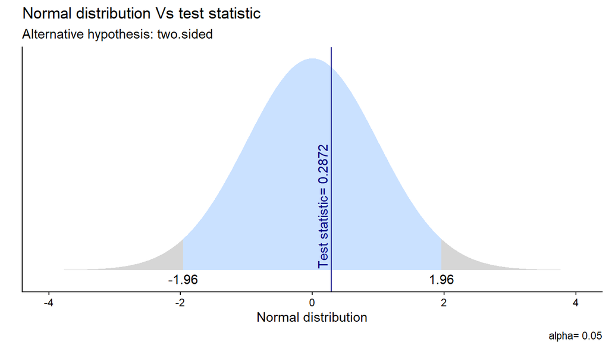

# Parte 2: Correlación de Pearson

## Correlación de Pearson

#### Concepto

La correlación de Pearson (r) mide la fuerza y dirección de la asociación lineal entre dos variables continuas.
$$r = \frac{\sum (x_i - \bar{x})(y_i - \bar{y})}{(n-1) \cdot s_x \cdot s_y}$$

## Test de correlación

### Pregunta: ¿Se relacionan los años de educación (`educyrs`) con el decil de ingreso (`income`)?

```r
# H0: r = 0 (No hay relación lineal)
# HA: r != 0 (Existe relación lineal)

cor_test_edu <- cor.test(issp$educyrs, issp$income,
                         method      = "pearson",
                         use = "complete.obs")

cor_test_edu
```

```
    Pearson's product-moment correlation

data:  issp$educyrs and issp$income
t = 15.77, df = 1103, p-value < 0.00000000000000022
alternative hypothesis: true correlation is not equal to 0
95 percent confidence interval:
 0.3795603 0.4758679
sample estimates:
      cor
0.4289321
```

## Tabla y visualización de cor.test

### Visualización con nice_table

```r
nice_table(tidy(cor_test_edu), broom = "cor.test")
```

| Method | Alternative | r | t | df | p | 95% CI |
| --- | --- | --- | --- | --- | --- | --- |
| Pearson's product-moment correlation | two.sided | .43 | 15.77 | 1,103 | < .001*** | [0.38, 0.48] |

## Tabla y visualización de cor.test

### Visualización con sjPlot

```r
sjPlot::plot_scatter(data = issp,
                     x = educyrs,
                     y = income)
```

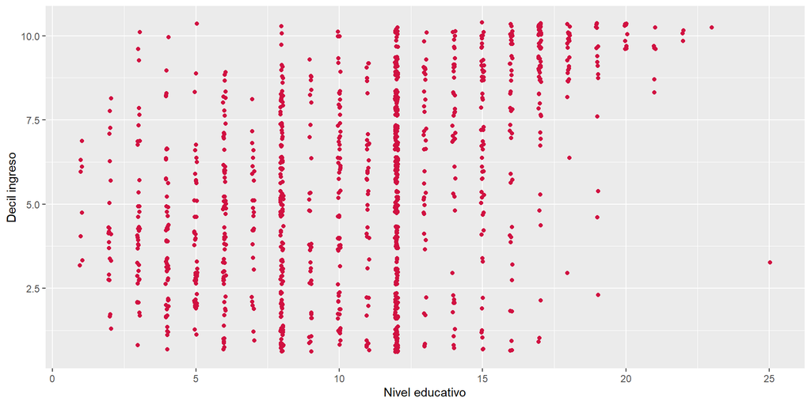

# Parte 3: Regresión lineal simple

## Modelo de regresión y cálculo de parámetros

El modelo de regresión se representa con una ecuación de la recta, o recta de regresión. Esta recta representa los valores predichos para Y según los distintos valores de X:

$$\widehat{Y} = b_{0} + b_{1}X$$

Donde

- $\widehat{Y}$ es el valor estimado/predicho de $Y$
- $b_{0}$ es el **intercepto** de la recta (el valor de Y cuando X es 0)
- $b_{1}$ es el **coeficiente de regresión**, que nos dice cuánto aumenta Y por cada punto que aumenta X (pendiente)

## Estimación del modelo de regresión simple en **R**

La función para estimar regresión en `R` es `lm` (linear model). Su forma general es:

```
objeto=lm(dependiente ~ independiente, data=datos)
```

Donde

- objeto: el nombre (cualquiera) que le damos al objeto donde se guardan los resultados de la estimación
- dependiente / independiente: los nombres de las variables en los datos
- data = el nombre del objeto de nuestros datos en R

### Ejemplo con nuestros datos:

```r
reg1 <- lm(topbot~educyrs, data=issp)

reg1
```

```
Call:
lm(formula = topbot ~ educyrs, data = issp)

Coefficients:
(Intercept)      educyrs
     2.4469       0.1504
```

### stargazer

Podemos tener un output en un formato más apropiado utilizando la librería stargazer

```r
stargazer(reg1, type = "text")
```

```
===============================================
                        Dependent variable:
                    ---------------------------
                              topbot
-----------------------------------------------
educyrs                      0.150***
                              (0.009)

Constant                     2.447***
                              (0.105)

-----------------------------------------------
Observations                   1,440
R2                             0.162
Adjusted R2                    0.161
Residual Std. Error      1.509 (df = 1438)
F Statistic          277.748*** (df = 1; 1438)
===============================================
Note:               *p<0.1; **p<0.05; ***p<0.01
```

El modelo estima que por cada año adicional de escolaridad, el estatus social subjetivo aumenta en promedio **0.15 puntos** en la escala de 1 a 10 (b = 0.150, p < 0.01).

La constante (2.447) representa el valor teórico de estatus social subjetivo para alguien con cero años de educación.

El R² indica que los años de educación explican aproximadamente el **16% de la variabilidad** en el estatus social subjetivo. Esto sugiere que la educación tiene una asociación positiva y estadísticamente significativa con cómo las personas se ubican en la jerarquía social.

### Scatterplot

```r
scatterplot(issp$topbot ~ issp$educyrs, data=issp, xlab="Educ", ylab="ESS", main="ESS on Educ", smooth=FALSE)
```

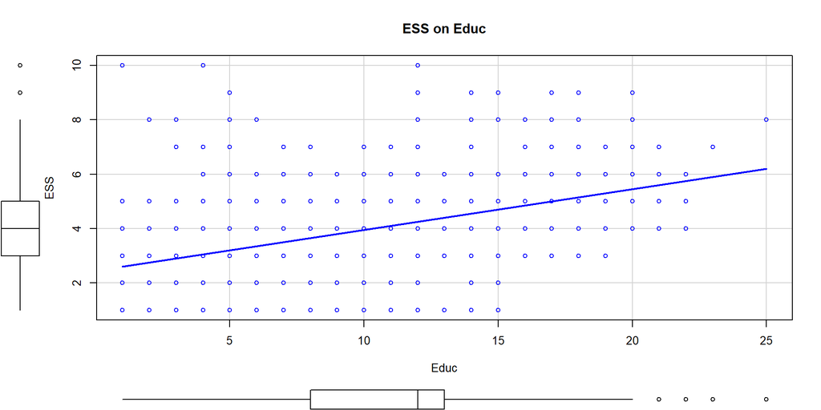

# Parte 4: Ejercicios aplicados

## Datos a utilizar

```r
tabla_issp <- sjmisc::descr(issp,
      show = c("label","range", "mean", "sd", "NA.prc", "n"))%>% # Selecciona estadísticos
  kable(.,"markdown" # Esto es para que se vea bien en quarto
  )

tabla_issp
```

|  | var | label | n | NA.prc | mean | sd | range |
| --- | --- | --- | --- | --- | --- | --- | --- |
| 11 | sex | Sexo | 1505 | 0.0000000 | 1.582060 | 0.4933842 | 1 (1-2) |
| 1 | age | Edad | 1505 | 0.0000000 | 46.561462 | 17.6353912 | 73 (18-91) |
| 6 | educyrs | Nivel educativo | 1451 | 3.5880399 | 10.762922 | 4.4097420 | 24 (1-25) |
| 7 | income | Decil ingreso | 1146 | 23.8538206 | 5.489529 | 2.8723002 | 9 (1-10) |
| 12 | topbot | Estatus social subjetivo | 1490 | 0.9966777 | 4.025503 | 1.6599884 | 9 (1-10) |
| 10 | pref_redis | Preferencia por redistribución | 1477 | 1.8604651 | 3.828030 | 0.8835747 | 4 (1-5) |
| 9 | perc_ineq | Percepción desigualdad | 1492 | 0.8637874 | 4.188338 | 0.8271374 | 4 (1-5) |
| 3 | conflict_rp | Conflictos: ricos - pobres | 1438 | 4.4518272 | 2.613352 | 0.8665370 | 3 (1-4) |
| 5 | conflict_wcmc | Conflictos: clase trabajadora - clase media | 1426 | 5.2491694 | 2.289621 | 0.8965377 | 3 (1-4) |
| 2 | conflict_mw | Conflictos: directivos - trabajadores | 1427 | 5.1827243 | 2.714085 | 0.8304120 | 3 (1-4) |
| 4 | conflict_tb | Conflictos: gente de arriba - gente de abajo | 1425 | 5.3156146 | 2.661754 | 0.9044854 | 3 (1-4) |
| 8 | perc_conflict | Percepción conflictos | 1390 | 7.6411960 | 6.295683 | 2.7935277 | 12 (0-12) |

## Ejercicio 1: T Test

### Pregunta: ¿Existen diferencias en los años de escolaridad (`educyrs`) según el sexo de los encuestados (`sex`)?

### Ej.1: Paso 0: Preparar datos

```r
issp_subset1 <- issp %>%
  dplyr::select(sex, educyrs) %>%
  na.omit()
```

### Tabla descriptiva

```r
issp_subset1 %>%
  dplyr::group_by(sex) %>%
  dplyr::summarise(
    Obs.     = n(),
    Promedio = round(mean(educyrs, na.rm = TRUE), 2),
    SD       = round(sd(educyrs, na.rm = TRUE), 2)
  ) %>%
  kableExtra::kable(
    format    = "markdown",
    align     = "c",
    col.names = c("Sexo", "N", "Promedio años educ.", "Desv. estándar"),
    caption   = "Tabla. Años de educación según sexo"
  ) %>%
  kableExtra::kable_classic(full_width = FALSE, font_size = 18)
```

Tabla. Años de educación según sexo

| Sexo | N | Promedio años educ. | Desv. estándar |
| --- | --- | --- | --- |
| 1 | 604 | 11.09 | 4.53 |
| 2 | 847 | 10.53 | 4.31 |

## Instrucciones:

1. Formula H0 y H1 en función de la pregunta
2. Ejecuta el test t con 95% de confianza
3. Presenta resultados con `nice_table()` y visualiza con `ggttest()`
4. Interpreta: ¿es posible rechazar H0?

## Ejercicio 2: Correlación

### Pregunta: ¿Qué relación existe entre el decil de ingreso (`income`) y la percepción de conflicto (`perc_conflict`)?

### Instrucciones:

1. Prepare un subset con las variables de interés
2. Genere una nube de puntos con `plot_scatter`
3. Formula H0 y H1 en función de la pregunta
4. Ejecuta el `cor.test` solo usando casos completos (sin NA)
5. Presenta resultados con `nice_table()`
6. Interpreta: ¿es posible rechazar H0?

## Ejercicio 3: Regresión

### Pregunta: ¿En qué medida los años de educación (`educyrs`) predicen el decil de ingreso (`income`)?

### Instrucciones:

1. Prepara un subset con ambas variables (sin NA)
2. Genera un gráfico de dispersión con plot_scatter
3. Estima el modelo con lm
4. Presenta resultados con stargazer
5. Interpreta: intercepto, pendiente, y R²; con sus respectivos niveles de significancia.

## Ejercicio 5: Regresión 2

### Pregunta: ¿En qué medida el estatus social subjetivo (`topbot`) predice la percepción de conflicto (`perc_conflict`)?

### Instrucciones:

1. Prepara el subset con ambas variables
2. Estima el modelo con lm()
3. Presenta los resultados con stargazer
4. Interpreta los coeficientes e indica si el modelo es estadísticamente significativo

## Ejercicio 6: Regresión 3

### Pregunta 2: ¿Cuál es la relación de la correlación y el R^2?

*Pista: para la pregunta 2, use el código `cor(base$variable, base$variable, use = "complete.obs`)*

# Resumen

### Acceso a [repositorio de ayudantías](https://github.com/Cristobal-Mejias-G/metodos-cuantitativos-fagob)

# Nos vemos en la próxima ayudantía. ¡Gracias por su atención!